# Assignment3_Jia

## Suggested answer for MATH 5472 Assignment 3

### Collected from one of my PhD students

## Problem (a)

The Lagrange of this constrained optimization problem is $$\sum_{i=1}^K\exp\left(-\frac{f_i(x)}{K-1}\right)\text{Prob}(c=i|x)-\lambda\sum_{i=1}^K f_i(x).$$ Taking derivatives with respect to $f_i$ and $\lambda$, we reach $$-\frac{1}{K-1}\exp\left(-\frac{f_i(x)}{K-1}\right)\text{Prob}(c=i|x)-\lambda=0,\,i=1,2,...,K,$$ $$\sum_{i=1}^K f_i(x)=0.$$ Solving this set of equations, we obtain the population minimizer $$f_i^*=(K-1)\left(\log\text{Prob}(c=i|x)-\frac1K\sum_{j=1}^K\log\text{Prob}(c=j|x)\right),\,i=1,2,...,K.$$ Based on the above equation, we reach two facts: $$\arg\max_i f_i^*(x)=\arg\max_i \text{Prob}(c=i|x),$$ and $$\text{Prob}(c=i|x)=\frac{\exp\left(\frac{1}{K-1}f_i^*(x)\right)}{\sum_{j=1}^K\exp\left(\frac{1}{K-1}f_j^*(x)\right)},\,i=1,2,...,K.$$

## Problem (b)

We consider f(x) that has the following form: $$f(x)=\sum_{m=1}^M\beta^{(m)}g^{(m)}(x),$$ where $\beta^{(m)}$ are coefficients, and $g^{(m)}(x)$ are basis functions. $g(x)$ is considered to take values in one of the $K$ possible $K$-dimensional vectors of the same forms as $y$. Then at each iteration, we need to compute $$\begin{aligned} (\beta^{(m)},g^{(m)}(x))&=\arg\min_{\beta,g}\sum_{i=1}^n L(y_i,f^{(m-1)}(x_i)+\beta g(x_i))\\ &=\arg\min_{\beta,g}\sum_{i=1}^n\exp\left(-\frac1K y_i^T(f^{(m-1)}(x)+\beta g(x_i))\right)\\ &=\arg\min_{\beta,g}\sum_{i=1}^n w_i\exp\left(-\frac1K\beta y_i^T g(x_i)\right), \end{aligned}$$ where $w_i=\exp\left(-\frac1K y_i^T f^{(m-1)}(x)\right)$. Notice that every $g(x)$ has a one-to-one correspondence with a multi-class classifier $T(x)$ in the following way: $$T(x)=k,\text{ if }g_k(x)=1,\text{ and vice versa}.$$ Based on the form of $g(x)$, we derive $$\begin{aligned} w_i\exp\left(-\frac1K\beta y_i^T g(x_i)\right)=&\sum_{c_i=T(x_i)}w_i\exp\left(-\frac{\beta}{K-1}\right) + \sum_{c_i\neq T(x_i)}w_i\exp\left(\frac{\beta}{(K-1)^2}\right)\\ =&\exp\left(-\frac{\beta}{K-1}\right)\sum_i^n w_i + \left(\exp\left(\frac{\beta}{(K-1)^2}\right)-\exp\left(-\frac{\beta}{K-1}\right)\right)\sum_{i=1}^n w_i\mathcal{I}(c_i\neq T(x_i)), \end{aligned}$$ which implies $$T^{(m)}(x)=\arg\min\sum_{i=1}^n w_i\mathcal{I}(c_i\neq T(x_i)),$$ $$\beta^{(m)}=\frac{(K-1)^2}{K}\left(\log\frac{1-r^{(m)}}{r^{(m)}}+\log(K-1)\right),$$ where $r^{m}$ is defined as $$r^{(m)}=\sum_{i=1}^n w_i\mathcal{I}(c_i\neq T(x_i))/\sum_{i=1}^n w_i.$$ Therefore, the multiclass boosting algorithm is written as

(1) Initialize ${w_i}$ by setting $w_i^{(1)}=1/n,\,i=1,2,...,n$, and initialize $f^{(1)}(x)=0.$

(2) For $m=1,2,...,M$:

(2.1) Fit a classifier $T^{(m)}(x)$ by $$T^{(m)}(x)=\arg\min\sum_{i=1}^n w_i\mathcal{I}(c_i\neq T(x_i)).$$

(2.2) Evaluate the quantities $$r^{(m)}=\sum_{i=1}^n w_i\mathcal{I}(c_i\neq T(x_i))/\sum_{i=1}^n w_i,$$ and then use these to evaluate $$\beta^{(m)}=\frac{(K-1)^2}{K}\left(\log\frac{1-r^{(m)}}{r^{(m)}}+\log(K-1)\right),$$ $$f^{(m+1)}(x)=f^{(m)}(x)+\beta^{(m)}g^{(m)}(x),$$ where $g^{(m)}(x_i)$ is induced by the classifier $T^{(m)}(x_i)$.

(2.3) Update the data weights $$w_i^{(m+1)}=w_i^{(m)}\exp\left(-\frac1K\beta^{(m)}y_i^T g^{(m)}(x_i)\right).$$

(3) Make prediction by $$F_M(x)=\arg\max_k f^{(M+1)}(x).$$

When $K=2$, the algorithm becomes very similar to Adaboost, as $$r^{(m)}=\sum_{i=1}^n w_i\mathcal{I}(c_i\neq T(x_i))/\sum_{i=1}^n w_i,$$ $$\beta^{(m)}=\frac12\left(\log\frac{1-r^{(m)}}{r^{(m)}}\right).$$

## Problem (c)

### Simulation (Mixture of Gaussians)

```python
import numpy as np
import numpy.random as npr
import matplotlib.pyplot as plt
import matplotlib
from sklearn.datasets import load_iris
from sklearn import tree
```

```python
# Simulation (Mixture of Gaussians)
n = 100
d = 2
X = np.zeros([n, 2])
y = np.zeros([n,])
for j in range(0, 50):
    X[j, :] = npr.normal(np.array([-0.8, -1]), 0.6 * np.ones([1, d]))
    y[j] = 0
for j in range(50, 80):
    X[j, :] = npr.normal(np.array([0.8, -1]), 0.6 * np.ones([1, d]))
    y[j] = 1
for j in range(80, 100):
    X[j, :] = npr.normal(np.array([0, 0.5]), 0.6 * np.ones([1, d]))
    y[j] = 2
X_mean = np.mean(X, axis=0)
X_sd = np.sqrt(np.var(X, axis=0))
X = np.array((X - X_mean) / X_sd)
```

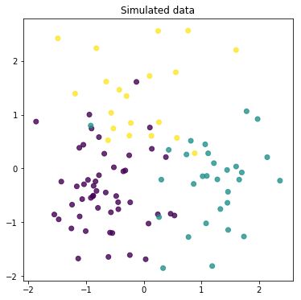

```python
plt.figure(num=3, figsize=(6, 6))
plt.scatter(X[:, 0], X[:, 1], c=y, alpha=0.8)
plt.title("Simulated data")
plt.show()
```

### Simple Tree Visualization

```
The predict_proba is:
[[0.74603175 0.01587302 0.23809524]
 [0.74603175 0.01587302 0.23809524]
 [0.74603175 0.01587302 0.23809524]]
The plot is:
```

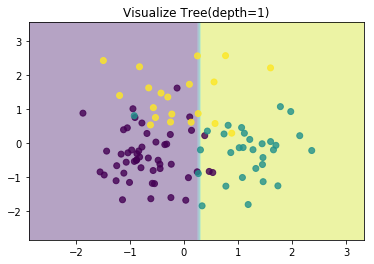

```python
clf = tree.DecisionTreeClassifier(max_depth=1)
clf = clf.fit(X, y)
print('The predict_proba is: ')
print(clf.predict_proba(X)[:3,:])
x_min, x_max = X[:, 0].min() - 1, X[:, 0].max() + 1
y_min, y_max = X[:, 1].min() - 1, X[:, 1].max() + 1
xx, yy = np.meshgrid(np.arange(x_min, x_max, 0.1),
                     np.arange(y_min, y_max, 0.1))
Z = clf.predict(np.c_[xx.ravel(), yy.ravel()])
Z = Z.reshape(xx.shape)
plt.contourf(xx, yy, Z, alpha=0.4)
plt.scatter(X[:, 0], X[:, 1], c=y, alpha=0.8)
plt.title("Visualize Tree(depth=1)")
print('The plot is:')
plt.show()
```

### Implementation of the derived algorithm in Problem (b)

```python
n_estimators = 100
learning_rate = 1.

n_samples = X.shape[0]
sample_weight = np.ones((n_samples,))
sample_weight /= sample_weight.sum()

estimators_ = []
estimator_weights_ = np.zeros(n_estimators) #alpha
estimator_errors_ = np.ones(n_estimators) #err

for iboost in range(n_estimators):
    # Boosting step
    estimator = tree.DecisionTreeClassifier(max_depth=1, random_state=0)
    estimator.fit(X, y, sample_weight=sample_weight)
    y_predict = estimator.predict(X)

    if iboost == 0:
        classes_ = getattr(estimator, 'classes_', None)
        n_classes_ = len(classes_)
        up_coff_incorrect = 1 / n_classes_
        up_coff_correct = - (n_classes_ - 1) / n_classes_
        coff_alpha = (n_classes_ - 1)**2 / n_classes_

    incorrect = y_predict != y
    correct = y_predict == y
    estimator_error = np.mean(np.average(incorrect, weights=sample_weight, axis=0)) #err
    if estimator_error <= 0:
        sample_weight = sample_weight
        estimator_weight = 1.0
        estimator_error = 0.0
    else:
        estimator_weight = learning_rate * (
            np.log((1. - estimator_error) / estimator_error) + np.log(n_classes_ - 1.)) #alpha
        # Only boost the weights if I will fit again
        if not iboost == n_estimators - 1:
            sample_weight *= np.exp((estimator_weight * incorrect * up_coff_incorrect * (sample_weight > 0)) +
                                   (estimator_weight * correct * up_coff_correct * (sample_weight > 0))) #w

    # Store
    estimator_weights_[iboost] = estimator_weight
    estimator_errors_[iboost] = estimator_error
    estimators_.append(estimator)

    # Stop if error is zero
    if estimator_error == 0:
        print("Stop, now error is zero.")
        break

    sample_weight_sum = np.sum(sample_weight)
    # Stop if the sum of sample weights has become non-positive
    if sample_weight_sum <= 0:
        print("Stop, the sum of sample weights has become non-positive.")
        break

    if iboost < n_estimators - 1:
        sample_weight /= sample_weight_sum
print('Total iters: %d.' % (iboost+1))


# Desicion function
def decision_function(X):
    classes = classes_[:, np.newaxis]
    pred = sum((estimator.predict(X) == classes - (1 - estimator.predict(X) == classes) / (n_classes_ - 1)).T * w * coff_alpha
               for estimator, w in zip(estimators_, estimator_weights_))
    pred /= estimator_weights_.sum()
    return pred


# Prediction function
def predict(X):
    pred = decision_function(X)
    return classes_.take(np.argmax(pred, axis=1), axis=0)
```

```
Total iters: 100.
```

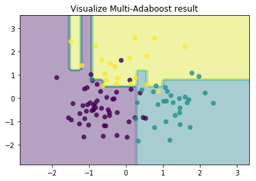

```python
# Visualize Multi-Adaboost result
x_min, x_max = X[:, 0].min() - 1, X[:, 0].max() + 1
y_min, y_max = X[:, 1].min() - 1, X[:, 1].max() + 1
xx, yy = np.meshgrid(np.arange(x_min, x_max, 0.1),
                     np.arange(y_min, y_max, 0.1))
Z = predict(np.c_[xx.ravel(), yy.ravel()])
Z = Z.reshape(xx.shape)
plt.contourf(xx, yy, Z, alpha=0.4)
plt.scatter(X[:, 0], X[:, 1], c=y, alpha=0.8)
plt.title("Visualize Multi-Adaboost result")
plt.show()
```

### AdaBoostClassifier in the package sklearn

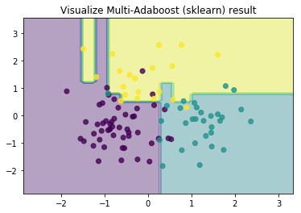

```python
from sklearn.ensemble import AdaBoostClassifier
clf = AdaBoostClassifier(n_estimators=100, random_state=0, algorithm='SAMME')
clf.fit(X, y)
x_min, x_max = X[:, 0].min() - 1, X[:, 0].max() + 1
y_min, y_max = X[:, 1].min() - 1, X[:, 1].max() + 1
xx, yy = np.meshgrid(np.arange(x_min, x_max, 0.1),
                     np.arange(y_min, y_max, 0.1))
Z = clf.predict(np.c_[xx.ravel(), yy.ravel()])
Z = Z.reshape(xx.shape)
plt.contourf(xx, yy, Z, alpha=0.4)
plt.scatter(X[:, 0], X[:, 1], c=y, alpha=0.8)
plt.title("Visualize Multi-Adaboost (sklearn) result")
plt.show()
```

### Comparison

```python
n = 100
d = 2
X_test = np.zeros([n, 2])
y_test = np.zeros([n,])
for j in range(0, 20):
    X_test[j, :] = npr.normal(np.array([-0.8, -1]), 0.6 * np.ones([1, d]))
    y_test[j] = 0
for j in range(20, 60):
    X_test[j, :] = npr.normal(np.array([0.8, -1]), 0.6 * np.ones([1, d]))
    y_test[j] = 1
for j in range(60, 100):
    X_test[j, :] = npr.normal(np.array([0, 0.5]), 0.6 * np.ones([1, d]))
    y_test[j] = 2
X_test = np.array((X_test - X_mean) / X_sd)
y_pred_b = predict(X_test)
y_pred_sklearn = clf.predict(X_test)
print('Prediction accuracy of algorithm in (b) is %4f' % (np.sum(y_pred_b == y_test) / n))
print('Prediction accuracy of AdaBoostClassifier in sklearn is %4f' % (np.sum(y_pred_sklearn == y_test) / n))
print('I observed that both the result visualization and the prediction accuracy of the two algorithms are same.')
```

```
Prediction accuracy of algorithm in (b) is 0.800000
Prediction accuracy of AdaBoostClassifier in sklearn is 0.800000
I observed that both the result visualization and the prediction accuracy of the two algorithms are same.
```